# project4Notebook_ExploratoryAnalysis_20jun

#### PROJECT 4: Communicate Data Findings

- Programmer/Analyst: Phyllis La Monica
- Course: Udacity Data Analyst Nanodegree
- DAND Project #4: Communicate Data Findings
- Date Submitted: 19 June 2019, Revised 20 June 2019

# Ford GoBike System Data

### by Phyllis La Monica

- Introduction
- Part 1. Preliminary Wrangling
  - Readiness Steps
  - Structure of Dataset
  - Main Interest
  - Features for Investigation
- Part 2. Exploratory Data Analysis
  - Preliminary Steps
  - Univariate Exploration, Summary
  - Bivariate Exploration, Summary
  - Multivariate Exploration, Summary
- References

## Introduction

The Ford GoBike System is a regional bike sharing system for the public. It covers the greater San Francisco Bay area in California. The dataset includes information about individual rides taken throughout the system.

This investigation looks at data for all of 2018.

- Data source: https://s3.amazonaws.com/baywheels-data/index.html

## Part I: Preliminary Wrangling

### Description of the Dataset:

This dataset explores Ford_GoBike System data, specifically bike-sharing information on individual rides taken in the San Francisco Bay area.

- Since the datasets are given for each month, wrangling will first create a master dataset that includes all of 2018.

```python
# Import all packages and set plots to be embedded inline
import os
import numpy as np
import pandas as pd
import matplotlib.pyplot as plt
import seaborn as sb

%matplotlib inline
from IPython.core.display import display
```

### Wrangling Readiness Steps: Create a master dataframe for Ford_GoBike 2018 data

1. Load each monthly Ford_GoBike dataset for 2018 into a pandas dataframe.
2. Use pandas concat() function to combine the individual monthly dataframes into one master dataframe for all of 2018 data.

#### Starting point: Create path to data, initialize list to hold 12 dataframes

#### Note:

#### The following wrangling procedure, to load monthly data using loop, was suggested by reviewer! Relay my thanks! Using a loop was quick, less error prone and simple compared to how I first loaded datasets, one by one for each month.

```python
# Path to data folder
path = '/Users/pphallen/Desktop/project4data'
```

```python
# Initialize list to hold monthly dataframes
dfs = []

# Loop over,load,append files in data directory, add conditional excluding misc/hidden files in diry
for file in os.listdir(path):
       if "-fordgobike-tripdata.csv" in file:
            file = os.path.join(path,file)
            df = pd.read_csv(file)
            dfs.append(df)

            # display information about each dataframe
            print(file)
            print('Shape: ', df.shape)
            display(df.head(1))
```

```
/Users/pphallen/Desktop/project4data/201802-fordgobike-tripdata.csv
Shape:  (106718, 16)
```

|  | duration_sec | start_time | end_time | start_station_id | start_station_name | start_station_latitude | start_station_longitude | end_station_id | end_station_name | end_station_latitude | end_station_longitude | bike_id | user_type | member_birth_year | member_gender | bike_share_for_all_trip |
| --- | --- | --- | --- | --- | --- | --- | --- | --- | --- | --- | --- | --- | --- | --- | --- | --- |
| 0 | 598 | 2018-02-28 23:59:47.0970 | 2018-03-01 00:09:45.1870 | 284 | Yerba Buena Center for the Arts (Howard St at ... | 37.784872 | -122.400876 | 114 | Rhode Island St at 17th St | 37.764478 | -122.40257 | 1035 | Subscriber | 1988.0 | Male | No |

```
/Users/pphallen/Desktop/project4data/201811-fordgobike-tripdata.csv
Shape:  (134135, 16)
```

|  | duration_sec | start_time | end_time | start_station_id | start_station_name | start_station_latitude | start_station_longitude | end_station_id | end_station_name | end_station_latitude | end_station_longitude | bike_id | user_type | member_birth_year | member_gender | bike_share_for_all_trip |
| --- | --- | --- | --- | --- | --- | --- | --- | --- | --- | --- | --- | --- | --- | --- | --- | --- |
| 0 | 79489 | 2018-11-30 13:40:32.7690 | 2018-12-01 11:45:21.9720 | NaN | NaN | 37.42 | -121.94 | NaN | NaN | 37.41 | -121.94 | 4105 | Customer | 1982.0 | Female | No |

```
/Users/pphallen/Desktop/project4data/201809-fordgobike-tripdata.csv
Shape:  (186217, 16)
```

|  | duration_sec | start_time | end_time | start_station_id | start_station_name | start_station_latitude | start_station_longitude | end_station_id | end_station_name | end_station_latitude | end_station_longitude | bike_id | user_type | member_birth_year | member_gender | bike_share_for_all_trip |
| --- | --- | --- | --- | --- | --- | --- | --- | --- | --- | --- | --- | --- | --- | --- | --- | --- |
| 0 | 76491 | 2018-09-30 18:37:01.7710 | 2018-10-01 15:51:53.5530 | 120.0 | Mission Dolores Park | 37.76142 | -122.426435 | 26.0 | 1st St at Folsom St | 37.78729 | -122.39438 | 903 | Customer | 1998.0 | Female | No |

```
/Users/pphallen/Desktop/project4data/201806-fordgobike-tripdata.csv
Shape:  (195968, 16)
```

|  | duration_sec | start_time | end_time | start_station_id | start_station_name | start_station_latitude | start_station_longitude | end_station_id | end_station_name | end_station_latitude | end_station_longitude | bike_id | user_type | member_birth_year | member_gender | bike_share_for_all_trip |
| --- | --- | --- | --- | --- | --- | --- | --- | --- | --- | --- | --- | --- | --- | --- | --- | --- |
| 0 | 59088 | 2018-06-30 23:32:44.6590 | 2018-07-01 15:57:33.3160 | 76.0 | McCoppin St at Valencia St | 37.771662 | -122.422423 | 95.0 | Sanchez St at 15th St | 37.766219 | -122.43106 | 2100 | Subscriber | 1975.0 | Male | Yes |

```
/Users/pphallen/Desktop/project4data/201805-fordgobike-tripdata.csv
Shape:  (179125, 16)
```

|  | duration_sec | start_time | end_time | start_station_id | start_station_name | start_station_latitude | start_station_longitude | end_station_id | end_station_name | end_station_latitude | end_station_longitude | bike_id | user_type | member_birth_year | member_gender | bike_share_for_all_trip |
| --- | --- | --- | --- | --- | --- | --- | --- | --- | --- | --- | --- | --- | --- | --- | --- | --- |
| 0 | 56791 | 2018-05-31 21:41:51.4750 | 2018-06-01 13:28:22.7220 | 44 | Civic Center/UN Plaza BART Station (Market St ... | 37.781074 | -122.411738 | 78 | Folsom St at 9th St | 37.773717 | -122.411647 | 1230 | Customer | NaN | NaN | No |

```
/Users/pphallen/Desktop/project4data/201812-fordgobike-tripdata.csv
Shape:  (131363, 16)
```

|  | duration_sec | start_time | end_time | start_station_id | start_station_name | start_station_latitude | start_station_longitude | end_station_id | end_station_name | end_station_latitude | end_station_longitude | bike_id | user_type | member_birth_year | member_gender | bike_share_for_all_trip |
| --- | --- | --- | --- | --- | --- | --- | --- | --- | --- | --- | --- | --- | --- | --- | --- | --- |
| 0 | 68529 | 2018-12-31 20:03:11.7350 | 2019-01-01 15:05:21.5580 | 217.0 | 27th St at MLK Jr Way | 37.817015 | -122.271761 | 217.0 | 27th St at MLK Jr Way | 37.817015 | -122.271761 | 3305 | Customer | NaN | NaN | No |

```
/Users/pphallen/Desktop/project4data/201801-fordgobike-tripdata.csv
Shape:  (94802, 16)
```

|  | duration_sec | start_time | end_time | start_station_id | start_station_name | start_station_latitude | start_station_longitude | end_station_id | end_station_name | end_station_latitude | end_station_longitude | bike_id | user_type | member_birth_year | member_gender | bike_share_for_all_trip |
| --- | --- | --- | --- | --- | --- | --- | --- | --- | --- | --- | --- | --- | --- | --- | --- | --- |
| 0 | 75284 | 2018-01-31 22:52:35.2390 | 2018-02-01 19:47:19.8240 | 120 | Mission Dolores Park | 37.76142 | -122.426435 | 285 | Webster St at O'Farrell St | 37.783521 | -122.431158 | 2765 | Subscriber | 1986.0 | Male | No |

```
/Users/pphallen/Desktop/project4data/201807-fordgobike-tripdata.csv
Shape:  (199222, 16)
```

|  | duration_sec | start_time | end_time | start_station_id | start_station_name | start_station_latitude | start_station_longitude | end_station_id | end_station_name | end_station_latitude | end_station_longitude | bike_id | user_type | member_birth_year | member_gender | bike_share_for_all_trip |
| --- | --- | --- | --- | --- | --- | --- | --- | --- | --- | --- | --- | --- | --- | --- | --- | --- |
| 0 | 59989 | 2018-07-31 18:20:32.7230 | 2018-08-01 11:00:22.1890 | 197.0 | El Embarcadero at Grand Ave | 37.808848 | -122.24968 | 181.0 | Grand Ave at Webster St | 37.811377 | -122.265192 | 1953 | Customer | 1995.0 | Male | No |

```
/Users/pphallen/Desktop/project4data/201808-fordgobike-tripdata.csv
Shape:  (192162, 16)
```

|  | duration_sec | start_time | end_time | start_station_id | start_station_name | start_station_latitude | start_station_longitude | end_station_id | end_station_name | end_station_latitude | end_station_longitude | bike_id | user_type | member_birth_year | member_gender | bike_share_for_all_trip |
| --- | --- | --- | --- | --- | --- | --- | --- | --- | --- | --- | --- | --- | --- | --- | --- | --- |
| 0 | 69465 | 2018-08-31 19:18:08.6130 | 2018-09-01 14:35:54.0640 | 3.0 | Powell St BART Station (Market St at 4th St) | 37.786375 | -122.404904 | 3.0 | Powell St BART Station (Market St at 4th St) | 37.786375 | -122.404904 | 813 | Customer | NaN | NaN | No |

```
/Users/pphallen/Desktop/project4data/201810-fordgobike-tripdata.csv
Shape:  (201458, 16)
```

|  | duration_sec | start_time | end_time | start_station_id | start_station_name | start_station_latitude | start_station_longitude | end_station_id | end_station_name | end_station_latitude | end_station_longitude | bike_id | user_type | member_birth_year | member_gender | bike_share_for_all_trip |
| --- | --- | --- | --- | --- | --- | --- | --- | --- | --- | --- | --- | --- | --- | --- | --- | --- |
| 0 | 80066 | 2018-10-31 20:49:03.1400 | 2018-11-01 19:03:30.0550 | 138.0 | Jersey St at Church St | 37.7509 | -122.427411 | 147.0 | 29th St at Tiffany Ave | 37.744067 | -122.421472 | 3458 | Customer | 1987.0 | Female | No |

```
/Users/pphallen/Desktop/project4data/201803-fordgobike-tripdata.csv
Shape:  (111382, 16)
```

|  | duration_sec | start_time | end_time | start_station_id | start_station_name | start_station_latitude | start_station_longitude | end_station_id | end_station_name | end_station_latitude | end_station_longitude | bike_id | user_type | member_birth_year | member_gender | bike_share_for_all_trip |
| --- | --- | --- | --- | --- | --- | --- | --- | --- | --- | --- | --- | --- | --- | --- | --- | --- |
| 0 | 71766 | 2018-03-31 16:58:33.1490 | 2018-04-01 12:54:39.2630 | 4 | Cyril Magnin St at Ellis St | 37.785881 | -122.408915 | 6 | The Embarcadero at Sansome St | 37.80477 | -122.403234 | 341 | Customer | 1964.0 | Female | No |

```
/Users/pphallen/Desktop/project4data/201804-fordgobike-tripdata.csv
Shape:  (131169, 16)
```

|  | duration_sec | start_time | end_time | start_station_id | start_station_name | start_station_latitude | start_station_longitude | end_station_id | end_station_name | end_station_latitude | end_station_longitude | bike_id | user_type | member_birth_year | member_gender | bike_share_for_all_trip |
| --- | --- | --- | --- | --- | --- | --- | --- | --- | --- | --- | --- | --- | --- | --- | --- | --- |
| 0 | 72393 | 2018-04-30 22:49:32.6180 | 2018-05-01 18:56:06.3010 | 4 | Cyril Magnin St at Ellis St | 37.785881 | -122.408915 | 4 | Cyril Magnin St at Ellis St | 37.785881 | -122.408915 | 3940 | Customer | NaN | NaN | No |

#### Use concat() function, create master dataframe: df_master.

```python
df_master = pd.concat(dfs)

# display information about the new dataframe
print('Shape: ', df_master.shape)
display(df_master.head(1))

df_master.info(null_counts=True)
```

```
Shape:  (1863721, 16)
```

|  | duration_sec | start_time | end_time | start_station_id | start_station_name | start_station_latitude | start_station_longitude | end_station_id | end_station_name | end_station_latitude | end_station_longitude | bike_id | user_type | member_birth_year | member_gender | bike_share_for_all_trip |
| --- | --- | --- | --- | --- | --- | --- | --- | --- | --- | --- | --- | --- | --- | --- | --- | --- |
| 0 | 598 | 2018-02-28 23:59:47.0970 | 2018-03-01 00:09:45.1870 | 284.0 | Yerba Buena Center for the Arts (Howard St at ... | 37.784872 | -122.400876 | 114.0 | Rhode Island St at 17th St | 37.764478 | -122.40257 | 1035 | Subscriber | 1988.0 | Male | No |

```
<class 'pandas.core.frame.DataFrame'>
Int64Index: 1863721 entries, 0 to 131168
Data columns (total 16 columns):
duration_sec               1863721 non-null int64
start_time                 1863721 non-null object
end_time                   1863721 non-null object
start_station_id           1851950 non-null float64
start_station_name         1851950 non-null object
start_station_latitude     1863721 non-null float64
start_station_longitude    1863721 non-null float64
end_station_id             1851950 non-null float64
end_station_name           1851950 non-null object
end_station_latitude       1863721 non-null float64
end_station_longitude      1863721 non-null float64
bike_id                    1863721 non-null int64
user_type                  1863721 non-null object
member_birth_year          1753003 non-null float64
member_gender              1753354 non-null object
bike_share_for_all_trip    1863721 non-null object
dtypes: float64(7), int64(2), object(7)
memory usage: 241.7+ MB
```

### Create copy of master dataframe: df.

```python
# Create copy of master dataframe, print shape, compare with master
df = df_master.copy()
print('df shape: ', df.shape)
print('df dtypes: ', df.dtypes)
```

```
df shape:  (1863721, 16)
df dtypes:  duration_sec                 int64
start_time                  object
end_time                    object
start_station_id           float64
start_station_name          object
start_station_latitude     float64
start_station_longitude    float64
end_station_id             float64
end_station_name            object
end_station_latitude       float64
end_station_longitude      float64
bike_id                      int64
user_type                   object
member_birth_year          float64
member_gender               object
bike_share_for_all_trip     object
dtype: object
```

```python
df.head(1)
```

|  | duration_sec | start_time | end_time | start_station_id | start_station_name | start_station_latitude | start_station_longitude | end_station_id | end_station_name | end_station_latitude | end_station_longitude | bike_id | user_type | member_birth_year | member_gender | bike_share_for_all_trip |
| --- | --- | --- | --- | --- | --- | --- | --- | --- | --- | --- | --- | --- | --- | --- | --- | --- |
| 0 | 598 | 2018-02-28 23:59:47.0970 | 2018-03-01 00:09:45.1870 | 284.0 | Yerba Buena Center for the Arts (Howard St at ... | 37.784872 | -122.400876 | 114.0 | Rhode Island St at 17th St | 37.764478 | -122.40257 | 1035 | Subscriber | 1988.0 | Male | No |

## Structure of dataset

### Main feature(s) of interest

My primary interest is learning about those who use the busiest 5 start_stations and on what days. Note: Start_stations are the point of rental origin. My secondary interest is learning how the characteristics of busiest and least busiest stations vary.

### Features that support this investigation.

Looking at gender, age, and user type will characterize those who use the stations of interest.

- I expect younger, male, subscribers will make up the majority of those using these stations.
- I expect many riders rent bikes to get to work, so Monday, as the beginning of the work week should be the busiest rider day, and weekdays in general busier than weekends.
- I expect the least busy start stations to mirror the characteristics of the busiest stations.

### Avoiding pitfalls__points to remember:

- The data presents information on the rides, and is not specific about individual users. All information is based on characteristics of the rental, not the rider.
- Rental durations are measured in minutes and do not relate to mileage.

## Exploratory Data Analysis

## Univariate Exploration

#### Preliminary Steps:

1. Drop unneeded columns for longitude, latitude, bike id
2. Create an 'age' column.
3. Convert date to datetime and create a 'dow' day-of-week column.
4. Create a column for duration in minutes, duration_min.
5. Create dataframes for the 5 busiest stations and the 5 least busiest stations.
6. Drop unneeded columns for longitude, latitude, bike id

### Prelim step 1: Drop unneeded columns for longitude, latitude, bike id

```python
columns = ['start_station_latitude','start_station_longitude','end_station_latitude','end_station_longitude','bike_id']
df.drop(columns, axis=1, inplace=True)
df.head(3)
```

|  | duration_sec | start_time | end_time | start_station_id | start_station_name | end_station_id | end_station_name | user_type | member_birth_year | member_gender | bike_share_for_all_trip |
| --- | --- | --- | --- | --- | --- | --- | --- | --- | --- | --- | --- |
| 0 | 598 | 2018-02-28 23:59:47.0970 | 2018-03-01 00:09:45.1870 | 284.0 | Yerba Buena Center for the Arts (Howard St at ... | 114.0 | Rhode Island St at 17th St | Subscriber | 1988.0 | Male | No |
| 1 | 943 | 2018-02-28 23:21:16.4950 | 2018-02-28 23:36:59.9740 | 6.0 | The Embarcadero at Sansome St | 324.0 | Union Square (Powell St at Post St) | Customer | 1987.0 | Male | No |
| 2 | 18587 | 2018-02-28 18:20:55.1900 | 2018-02-28 23:30:42.9250 | 93.0 | 4th St at Mission Bay Blvd S | 15.0 | San Francisco Ferry Building (Harry Bridges Pl... | Customer | 1986.0 | Female | No |

```python
df.duration_sec.value_counts(bins=20)
```

```
(-25.306, 4376.25]     1838787
(4376.25, 8691.5]        14351
(8691.5, 13006.75]        4186
(13006.75, 17322.0]       1952
(17322.0, 21637.25]        984
(21637.25, 25952.5]        579
(25952.5, 30267.75]        420
(30267.75, 34583.0]        280
(34583.0, 38898.25]        244
(56159.25, 60474.5]        215
(43213.5, 47528.75]        209
(38898.25, 43213.5]        203
(47528.75, 51844.0]        201
(51844.0, 56159.25]        196
(60474.5, 64789.75]        188
(64789.75, 69105.0]        171
(69105.0, 73420.25]        159
(73420.25, 77735.5]        151
(77735.5, 82050.75]        126
(82050.75, 86366.0]        119
Name: duration_sec, dtype: int64
```

### Prelim step 2: Create an 'age' column. Use age instead of birth year to improve clarity.

```python
# Use pandas apply method and lambda fct

df['age'] = df.apply(lambda row: row.member_birth_year * (-1) + 2019 , axis=1)

# Confirm dtype
print('column: age dtype:',df.age.dtype)

df.head(3)
```

```
column: age dtype: float64
```

|  | duration_sec | start_time | end_time | start_station_id | start_station_name | end_station_id | end_station_name | user_type | member_birth_year | member_gender | bike_share_for_all_trip | age |
| --- | --- | --- | --- | --- | --- | --- | --- | --- | --- | --- | --- | --- |
| 0 | 598 | 2018-02-28 23:59:47.0970 | 2018-03-01 00:09:45.1870 | 284.0 | Yerba Buena Center for the Arts (Howard St at ... | 114.0 | Rhode Island St at 17th St | Subscriber | 1988.0 | Male | No | 31.0 |
| 1 | 943 | 2018-02-28 23:21:16.4950 | 2018-02-28 23:36:59.9740 | 6.0 | The Embarcadero at Sansome St | 324.0 | Union Square (Powell St at Post St) | Customer | 1987.0 | Male | No | 32.0 |
| 2 | 18587 | 2018-02-28 18:20:55.1900 | 2018-02-28 23:30:42.9250 | 93.0 | 4th St at Mission Bay Blvd S | 15.0 | San Francisco Ferry Building (Harry Bridges Pl... | Customer | 1986.0 | Female | No | 33.0 |

```python
# To convert float to int6 dype first find and fill NaN entries
```

```python
# Find any NaNs
print('df.age.isna().sum(): ',df.age.isna().sum() )
print('df.age.notna().sum(): ',df.age.notna().sum() )
df.age.dtype
```

```
df.age.isna().sum():  110718
df.age.notna().sum():  1753003
```

```
dtype('float64')
```

```python
# Convert dtype to int after filling in NaNs
df['age'] = df['age'].fillna(0).astype(int)
df.age.dtype
```

```
dtype('int64')
```

```python
# Identify age outliers -- may remove after reviewing visualization
print('youngest user age: ',df.age.min() )
print('oldest user age: ',df.age.max() )
```

```
youngest user age:  0
oldest user age:  138
```

```python
df.age.value_counts(bins=5)
```

```
(27.6, 55.2]      1288385
(-0.139, 27.6]     472814
(55.2, 82.8]       100095
(82.8, 110.4]        1551
(110.4, 138.0]        876
Name: age, dtype: int64
```

### Prelim step 3: Convert date to datetime and create a 'day_started' showing day-of-week.

#### Use pandas: split start_time column. Create cols: date_started, time_started.

```python
# Create new columns then create day of week columns.

df['date_started'] = pd.to_datetime(df['start_time']).dt.date
df['time_started'] = pd.to_datetime(df['start_time']).dt.time

df.head(2)
```

|  | duration_sec | start_time | end_time | start_station_id | start_station_name | end_station_id | end_station_name | user_type | member_birth_year | member_gender | bike_share_for_all_trip | age | date_started | time_started |
| --- | --- | --- | --- | --- | --- | --- | --- | --- | --- | --- | --- | --- | --- | --- |
| 0 | 598 | 2018-02-28 23:59:47.0970 | 2018-03-01 00:09:45.1870 | 284.0 | Yerba Buena Center for the Arts (Howard St at ... | 114.0 | Rhode Island St at 17th St | Subscriber | 1988.0 | Male | No | 31 | 2018-02-28 | 23:59:47.097000 |
| 1 | 943 | 2018-02-28 23:21:16.4950 | 2018-02-28 23:36:59.9740 | 6.0 | The Embarcadero at Sansome St | 324.0 | Union Square (Powell St at Post St) | Customer | 1987.0 | Male | No | 32 | 2018-02-28 | 23:21:16.495000 |

```python
# Create new column showing day of week (int) rental started
# https://stackoverflow.com/questions/46515267/pandas-get-day-of-week-from-date-type-column
# ref: pandas doc -- "Return the day of the week as an integer, where Monday is 0 and Sunday is 6."

df['day_started']= pd.to_datetime(df['date_started']).dt.dayofweek
df.head(2)
```

|  | duration_sec | start_time | end_time | start_station_id | start_station_name | end_station_id | end_station_name | user_type | member_birth_year | member_gender | bike_share_for_all_trip | age | date_started | time_started | day_started |
| --- | --- | --- | --- | --- | --- | --- | --- | --- | --- | --- | --- | --- | --- | --- | --- |
| 0 | 598 | 2018-02-28 23:59:47.0970 | 2018-03-01 00:09:45.1870 | 284.0 | Yerba Buena Center for the Arts (Howard St at ... | 114.0 | Rhode Island St at 17th St | Subscriber | 1988.0 | Male | No | 31 | 2018-02-28 | 23:59:47.097000 | 2 |
| 1 | 943 | 2018-02-28 23:21:16.4950 | 2018-02-28 23:36:59.9740 | 6.0 | The Embarcadero at Sansome St | 324.0 | Union Square (Powell St at Post St) | Customer | 1987.0 | Male | No | 32 | 2018-02-28 | 23:21:16.495000 | 2 |

### Prelim step 4: Create a column for duration in minutes, duration_min.

```python
# Use pandas apply method and lambda fct to convert seconds to minutes & create min col
df['duration_min'] = df.apply(lambda row: row.duration_sec / 60, axis=1)

print('column: duration_min dtype:',df.duration_min.dtype)
df.duration_min = df.duration_min.astype(int)
print('confirm duration_min convert dtype to int: ',df.duration_min.dtype)
df.head(2)
```

```
column: duration_min dtype: float64
confirm duration_min convert dtype to int:  int64
```

|  | duration_sec | start_time | end_time | start_station_id | start_station_name | end_station_id | end_station_name | user_type | member_birth_year | member_gender | bike_share_for_all_trip | age | date_started | time_started | day_started | duration_min |
| --- | --- | --- | --- | --- | --- | --- | --- | --- | --- | --- | --- | --- | --- | --- | --- | --- |
| 0 | 598 | 2018-02-28 23:59:47.0970 | 2018-03-01 00:09:45.1870 | 284.0 | Yerba Buena Center for the Arts (Howard St at ... | 114.0 | Rhode Island St at 17th St | Subscriber | 1988.0 | Male | No | 31 | 2018-02-28 | 23:59:47.097000 | 2 | 9 |
| 1 | 943 | 2018-02-28 23:21:16.4950 | 2018-02-28 23:36:59.9740 | 6.0 | The Embarcadero at Sansome St | 324.0 | Union Square (Powell St at Post St) | Customer | 1987.0 | Male | No | 32 | 2018-02-28 | 23:21:16.495000 | 2 | 15 |

```python
df.duration_min.value_counts(bins=10)
```

```
(-0.439, 144.8]     1853153
(144.8, 288.6]         6128
(288.6, 432.4]         1559
(432.4, 576.2]          701
(576.2, 720.0]          447
(863.8, 1007.6]         411
(720.0, 863.8]          408
(1007.6, 1151.4]        360
(1151.4, 1295.2]        310
(1295.2, 1439.0]        244
Name: duration_min, dtype: int64
```

### Prelim step 5: Create dataframes for 5 busiest and least busiest station ids

```python
# Use groupby, get list of top 5 busiest station ids and show corresponding station names

df['start_station_name'].groupby(df['start_station_id']).value_counts().nlargest(5)
```

```
start_station_id  start_station_name
15.0              San Francisco Ferry Building (Harry Bridges Plaza)           38461
67.0              San Francisco Caltrain Station 2  (Townsend St at 4th St)    37617
30.0              San Francisco Caltrain (Townsend St at 4th St)               35092
58.0              Market St at 10th St                                         34918
81.0              Berry St at 4th St                                           33716
Name: start_station_name, dtype: int64
```

```python
# Use pandas query to create dataframe for 5  busiest stations

# http://pandas-docs.github.io/pandas-docs-travis/user_guide/indexing.html#the-query-method
#Special use of the == operator with list objects

df_busy = df.query('start_station_id == ["30","15","81","58","67"]')
df_busy.head(3)
df_busy.info()
```

```
<class 'pandas.core.frame.DataFrame'>
Int64Index: 179804 entries, 83 to 131165
Data columns (total 16 columns):
duration_sec               179804 non-null int64
start_time                 179804 non-null object
end_time                   179804 non-null object
start_station_id           179804 non-null float64
start_station_name         179804 non-null object
end_station_id             179804 non-null float64
end_station_name           179804 non-null object
user_type                  179804 non-null object
member_birth_year          168677 non-null float64
member_gender              168683 non-null object
bike_share_for_all_trip    179804 non-null object
age                        179804 non-null int64
date_started               179804 non-null object
time_started               179804 non-null object
day_started                179804 non-null int64
duration_min               179804 non-null int64
dtypes: float64(3), int64(4), object(9)
memory usage: 23.3+ MB
```

```python
# Confirm only start_station_ids are included
df_busy.start_station_id.value_counts()
```

```
15.0    38461
67.0    37617
30.0    35092
58.0    34918
81.0    33716
Name: start_station_id, dtype: int64
```

```python
# Use groupby, get list of 5 least busiest station ids and show corresponding station names -- See comment following cell.
df['start_station_name'].groupby(df['start_station_id']).value_counts().nsmallest(7)
```

```
start_station_id  start_station_name
48.0              2nd St at S Park St                          11
234.0             Farnam St at Fruitvale Ave                   14
358.0             Williams Ave at 3rd St                       17
374.0             Viva Calle SJ                                25
208.0             William St at 4th St (Temporary Location)    26
358.0             Lane St at Van Dyke Ave                      35
359.0             Williams Ave at Apollo St                    91
Name: start_station_name, dtype: int64
```

#### RE: least busy stations -- excluded is temporary location 208. As station 358 is listed twice (& counts are low) station 359 is added.

```python
###### Use pandas query to create dataframe for 5 least busiest stations

# http://pandas-docs.github.io/pandas-docs-travis/user_guide/indexing.html#the-query-method
# Special use of the == operator with list objects

df_notBusy = df.query('start_station_id == ["48","234","358","359", "374"]')
df_notBusy.head()
df_notBusy.info()
```

```
<class 'pandas.core.frame.DataFrame'>
Int64Index: 353 entries, 7373 to 111122
Data columns (total 16 columns):
duration_sec               353 non-null int64
start_time                 353 non-null object
end_time                   353 non-null object
start_station_id           353 non-null float64
start_station_name         353 non-null object
end_station_id             353 non-null float64
end_station_name           353 non-null object
user_type                  353 non-null object
member_birth_year          328 non-null float64
member_gender              328 non-null object
bike_share_for_all_trip    353 non-null object
age                        353 non-null int64
date_started               353 non-null object
time_started               353 non-null object
day_started                353 non-null int64
duration_min               353 non-null int64
dtypes: float64(3), int64(4), object(9)
memory usage: 46.9+ KB
```

```python
# Confirm only listed start_station_ids are included
df_notBusy.start_station_id.value_counts()
```

```
234.0    174
359.0     91
358.0     52
374.0     25
48.0      11
Name: start_station_id, dtype: int64
```

## Univariate exploration for main focus variable: start_station_id

#### ...

#### Dataframes: df_busy, df_notBusy

#### Plot frequencies for each start station to compare similarities and differences.

```python
# Show counts for main variables of interest: where the ride starts,  start_station_id
# Plot main variable of interest using bar chart of frequencies
```

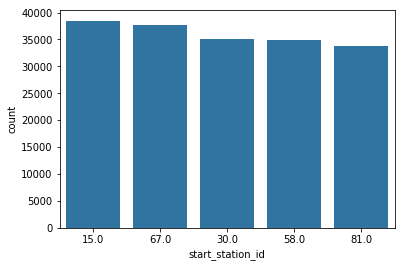

```python
orderStations= df_busy['start_station_id'].value_counts().nlargest(5)
orderBusy = orderStations.index

base_color = sb.color_palette()[0]
sb.countplot(data = df_busy, x = 'start_station_id', order=orderBusy, color=base_color);
```

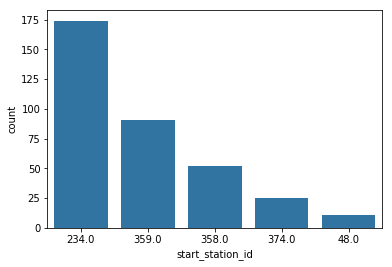

```python
orderStations= df_notBusy['start_station_id'].value_counts().nlargest(5)
order_notBusy = orderStations.index

base_color = sb.color_palette()[0]
sb.countplot(data = df_notBusy, x = 'start_station_id', order=order_notBusy, color=base_color);
```

#### Comments: busiest stations show a consistency in rider counts not seen for the least busiest.

## Univariate Exploration of characterizing features

### age

#### Explore by dataframe. Look first at df_busy, then df_notBusy

```python
# First look at stats and ranges of age distribution for df_busy
df_busy.age.describe()

print('Youngest user age: ',df_busy.age.min() )
print('Oldest user age: ',df_busy.age.max() )
print('Mean user age: ',df_busy.age.mean() )
```

```
Youngest user age:  0
Oldest user age:  130
Mean user age:  34.42606393628618
```

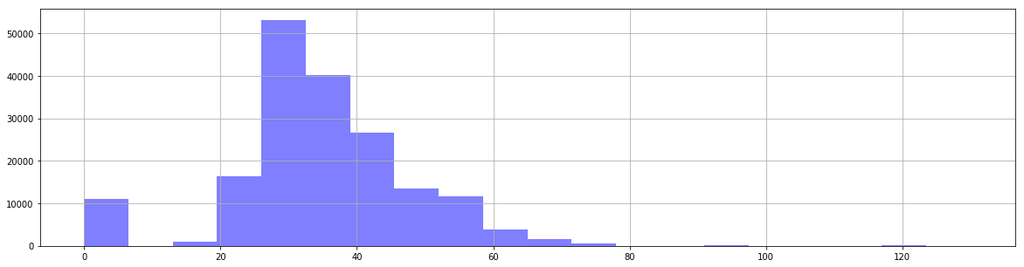

```python
# Plot age frequency for df_busy
plt.figure(figsize=[20,5])
df_busy['age'].hist(alpha=0.5, bins=20,color='blue', label='Age') ;
```

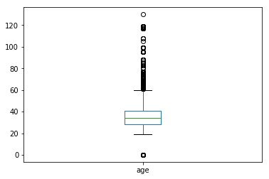

```python
df_busy['age'].plot(kind='box'); # df_busy
```

#### These visualizations for the dataframe, df_busy, show outliers at both ends of the spectrum that are clearly not part of the main group in the distribution.

#### ...

#### Next explore the same visualizations for the least busy stations

```python
# First look at stats and ranges of age distribution for df_notBusy
df_notBusy.age.describe()

print('Youngest user age: ',df_notBusy.age.min() )
print('Oldest user age: ',df_notBusy.age.max() )
print('Mean user age: ',df_notBusy.age.mean() )
```

```
Youngest user age:  0
Oldest user age:  72
Mean user age:  32.611898016997166
```

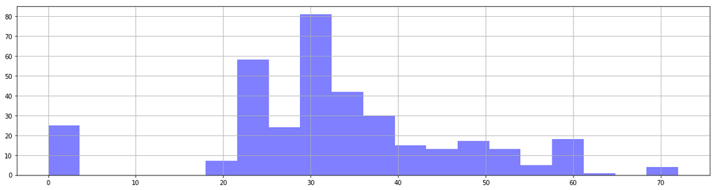

```python
#Plot age frequency for df_notBusy
plt.figure(figsize=[20,5])
df_notBusy['age'].hist(alpha=0.5, bins=20,color='blue', label='Age') ;
```

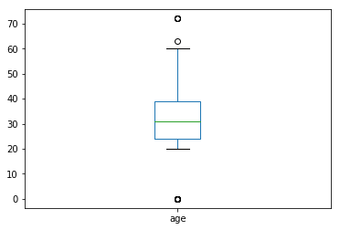

```python
df_notBusy['age'].plot(kind='box');  # df_notBusy
```

#### The visualizations for the dataframe, df_notBusy, show outliers that clearly are separated at left & right tails of the distribution.

#### ...

#### Before going forward explore removing the outliers. The age range of 0 to 130 clearly includes non-living riders.

#### Data from visualizations and stats shows natural breaks before teenage years and ages above 80.

#### Create an age group > 13, and <81 for both dataframes so the main groups in each distribution are more clearly delineated.

```python
# Create age group for df_busy: df_age_busy
df_age_busy = df_busy.query(' 13 < age < 81')

print('Youngest user age: ',df_age_busy.age.min() )
print('Oldest user age: ',df_age_busy.age.max() )
print('Mean user age: ',df_age_busy.age.mean() )
```

```
Youngest user age:  19
Oldest user age:  80
Mean user age:  36.57806774245277
```

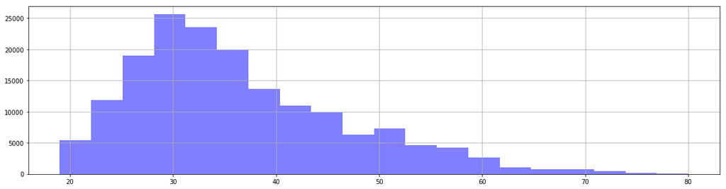

```python
# Plot age group for df_age_busy
plt.figure(figsize=[20,5])
df_age_busy['age'].hist(alpha=0.5, bins=20,color='blue', label='Age') ;
```

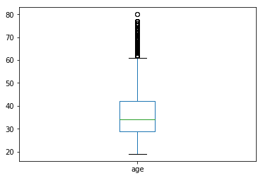

```python
df_age_busy['age'].plot(kind='box'); # df_age_busy
```

#### Creating a specific age group for the dataframe, df_busy, shows a more oompact, right tail distribution. It is practical that riders over 70 be included as this age group is known to be active.

#### ...

#### Explore least busiest stations, df_notBusy

```python
# Repeat steps for least busiest station, df_notBusy
# Create new age group, df_age_notBusy
df_age_notBusy = df_notBusy.query(' 13 < age < 81')

print('Youngest user age: ',df_age_notBusy.age.min() )
print('Oldest user age: ',df_age_notBusy.age.max() )
print('Mean user age: ',df_age_notBusy.age.mean() )
```

```
Youngest user age:  20
Oldest user age:  72
Mean user age:  35.09756097560975
```

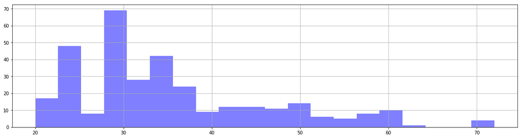

```python
# Plot age group for df_notBusy
plt.figure(figsize=[20,5])
df_age_notBusy['age'].hist(alpha=0.5, bins=20,color='blue', label='Age') ;
```

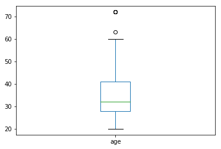

```python
df_age_notBusy['age'].plot(kind='box'); # df_age_notBusy
```

#### The distribution of the specific age group for least busiest stations also tails to the right and shows a gap in the 60 to 70 age group. Also, there is a noticeable drop in the 20 to 30 age group. This can be explored in the bi- and multi- variate stages.

#### Comments:

#### The distribution for busiest start stations is consistent, the distribution for the least busy is 'choppy'. A consistent distribution surrounding the mean would lean toward users who rent daily to get to work.

#### Removing the outliers for age shows a more compact distribution for each dataframe.

#### It may be that creating a new 'grouped_age' column for each dataframe will be indicated. Leave as is for now.

#### ...

### user_type

```python
# Busiest stations: show value counts for type of users for df_busy
df_busy.user_type.value_counts()
```

```
Subscriber    153596
Customer       26208
Name: user_type, dtype: int64
```

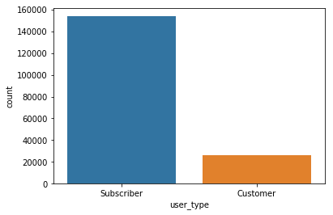

```python
# Busiest stations, plot type of users for df_busy
sb.countplot(data = df_busy, x = 'user_type')
```

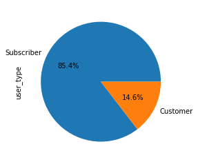

```python
df_busy.user_type.value_counts().plot(kind='pie', autopct='%1.1f%%') ;  # df_busy
```

#### The pattern clearly indicates riders at the busiest start stations are more likely to be subscribers to the service.

#### ...

#### Explore df_notBusy

```python
# Least busiest stations: show value counts for type of users for df_notBusy
```

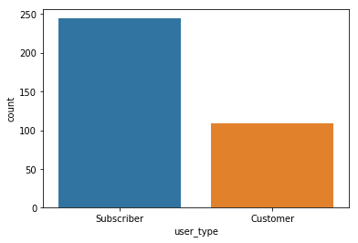

```python
# Least busiest stations, plot type of users for df_notBusy
sb.countplot(data = df_notBusy, x = 'user_type');
```

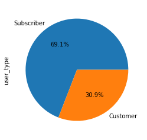

```python
df_notBusy.user_type.value_counts().plot(kind='pie', autopct='%1.1f%%') ; # df_notBusy
```

#### Interesting, but not surprising, that the least busy stations are also used by subscribers.

#### ...

#### Comments: Clearly, more subscribers than customers rent bikes, regardless of station type. However the proportion for the busiest start stations is higher at 85.4% as opposed to least busiest at 69.1%.

#### It could be useful to explore which user types ride on which days.

#### ...

### member_gender

```python
# Busiest stations: show value counts for gender type for df_busy
df_busy.member_gender.value_counts()
```

```
Male      128353
Female     38865
Other       1465
Name: member_gender, dtype: int64
```

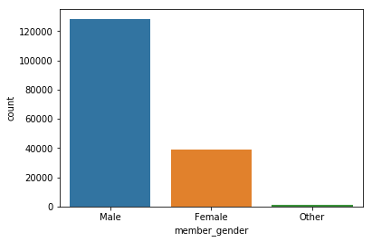

```python
# Busiest stations, plot gender of users for df_busy
sb.countplot(data = df_busy, x = 'member_gender');
```

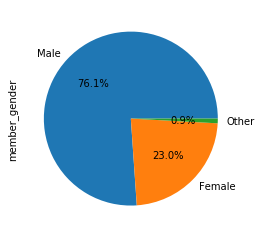

```python
df_busy.member_gender.value_counts().plot(kind='pie', autopct='%1.1f%%') ; # df_busy
```

#### Males comprise the largest group of riders at the busiest start stations.

#### ...

#### Explore df_notBusy

```python
# Least busiest stations: show value counts for gender type for df_notBusy
df_notBusy.member_gender.value_counts()
```

```
Male      251
Female     68
Other       9
Name: member_gender, dtype: int64
```

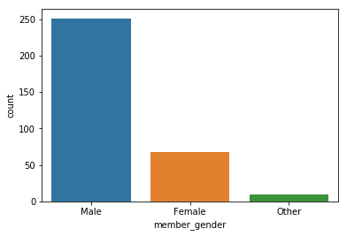

```python
# Least busiest stations, plot gender of users for df_notBusy
sb.countplot(data = df_notBusy, x = 'member_gender');
```

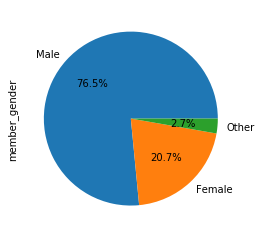

```python
df_notBusy.member_gender.value_counts().plot(kind='pie', autopct='%1.1f%%') ; # df_notBusy
```

#### Males also comprise the greater majority of riders at the least busiest start stations.

#### ...

#### Comments: Proportions for gender use of busiest and least busiest start stations are so similar the differences are not significant. It would be interesting to learn if there is the same pattern for days on which rentals are made.

### day_started

```python
# Busiest stations: show value counts for day rental started for df_busy
df_busy.day_started.value_counts(ascending=False)
```

```
1    34099
2    33199
3    32897
0    30921
4    28941
5    10983
6     8764
Name: day_started, dtype: int64
```

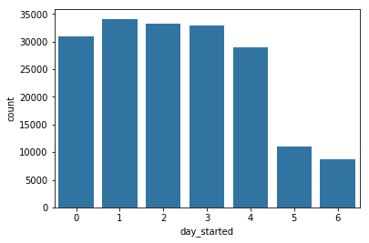

```python
# Busiest stations, plot day rental started for df_busy
# Day - listed in order of day: 0 = monday

base_color = sb.color_palette()[0]
sb.countplot(data = df_busy, x = 'day_started', color = base_color);
```

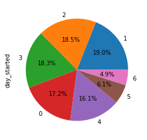

```python
df_busy.day_started.value_counts().plot(kind='pie', autopct='%1.1f%%') ; # df_busy
```

#### ...

#### Explore df_notBusy

```python
# Busiest stations: show value counts for day rental started for df_notBusy
df_notBusy.day_started.value_counts(ascending=False)
```

```
6    66
3    61
2    51
0    51
4    46
5    40
1    38
Name: day_started, dtype: int64
```

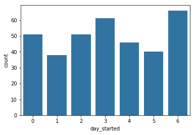

```python
# Least Busiest stations, plot day rental started for df_notBusy
# Day - listed in order of day: 0 = monday

base_color = sb.color_palette()[0]
sb.countplot(data = df_notBusy, x = 'day_started', color = base_color);
```

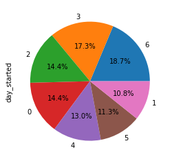

```python
df_notBusy.day_started.value_counts().plot(kind='pie', autopct='%1.1f%%') ; # df_notBusy
```

#### ...

#### Comments: Busiest stations do have consistent daily work week traffic that drops off considerably on the weekend. Least busy stations have an irregular pattern with higher rentals on Sundays. It would be interesting to know how the day of rental relates to gender use.

#### ...

### duration_min

```python
# Look at duration_min stats and ranges for df_busy
df_busy.duration_min.describe()

#print('Minimum rental interval: ',df_busy.duration_min.min() )  # Minimum rental interval:  1
#print('Maximum rental interval: ',df_busy.duration_min.max() )  # Maximum rental interval:  1423
#print('Mean rental interval: ',df_busy.duration_min.mean() ) # Mean rental interval:  13.755867500166849
```

```
count    179804.000000
mean         13.755868
std          35.627812
min           1.000000
25%           7.000000
50%          10.000000
75%          13.000000
max        1423.000000
Name: duration_min, dtype: float64
```

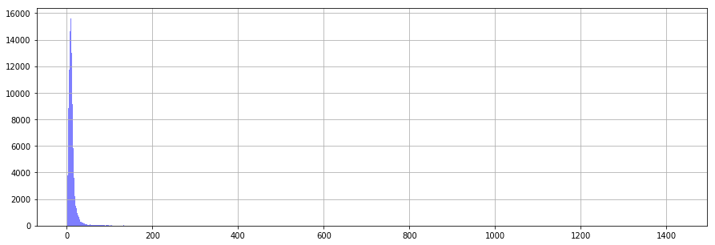

```python
# Plot duration_min for df_busy
plt.figure(figsize=[15,5])
df_busy['duration_min'].hist(alpha=0.5,  bins = int(1423/1),color='blue', label='Rental Interval in Minutes') ;
```

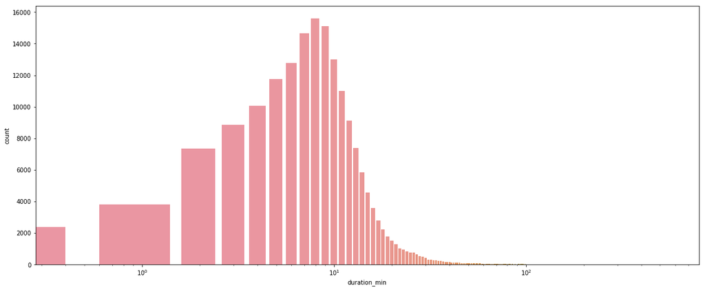

```python
# Use log transformation and countplot to make data readable.
# Typically used for skewed data, here used to clarify the data.
plt.figure(figsize=[20,8])
sb.countplot(data = df_busy, x = 'duration_min')
plt.xscale('log');
```

#### Rental durations tracked for the busiest start stations have a mean of 13.7 minutes., with 75% of durations being 13 minutes or less (ref: duration_min.describe] . Using the countplot with minutes shown in a log transformation clarifies the counts.

#### ...

#### Explore df_notBusy

```python
# Look at duration_min stats and ranges for df_notBusy
df_notBusy.duration_min.describe()

#print('Minimum rental interval: ',df_notBusy.duration_min.min() )  # Minimum rental interval:  1
#print('Maximum rental interval: ',df_notBusy.duration_min.max() )  # Maximum rental interval:  937
#print('Mean rental interval: ',df_notBusy.duration_min.mean() ) # Mean rental interval: 26.93484419263456
```

```
count    353.000000
mean      26.934844
std       65.110385
min        1.000000
25%        5.000000
50%       17.000000
75%       30.000000
max      937.000000
Name: duration_min, dtype: float64
```

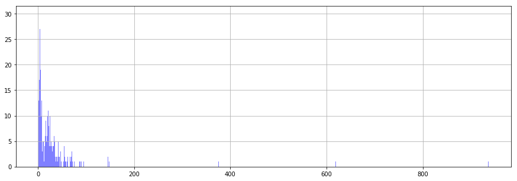

```python
# Plot duration_min for df_notBusy
# Use bin size of 1 minute length, as used for busiest station, to keep a similarity.
plt.figure(figsize=[15,5])
df_notBusy['duration_min'].hist(alpha=0.5,  bins = int(937/1),color='blue', label='Rental Interval in Minutes') ;
```

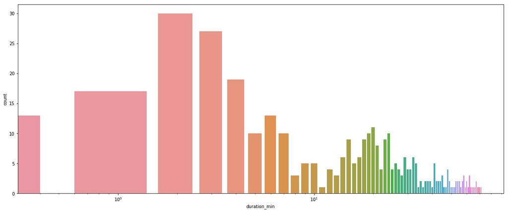

```python
# Use log transformation to make data readable
plt.figure(figsize=[20,8])
sb.countplot(data = df_notBusy, x = 'duration_min')
plt.xscale('log');
```

#### The histogram for least busiest start stations shows a wider rental duration range, where the mean is 26 minutes and 75% of the durations being 30 minutes or less (ref:duration_min.describe). Using the countplot with minutes shown in a log transformation clarifies the counts.

### ...

#### Comment: There is a clear difference in rental durations for busiest and least busiest start station. Busiest stations have shorter rental durations, with 75% of rental durations at 13 minutes or less.

From .describe stats:

- Busiest start stations: mean=13.7 minutes, 75% of rental durations=13 minutes.
- Least busiest start stations: mean=26 minutes, 75% of rental durations=30. minutes.

#### ...

## End Univariate Exploration

### Discussion

  ### Questions to keep in mind for bivariate explorations
  - Does 'age' need to be narrowed in range in visualizations with other characteristics?
  - Which user_types ride on which days? There is a greater proportion of subscribers renting at the busiest start stations than at the least busiest.
  - Males comprise the majority of renters at both busiest and least busiest start stations. Are there days when that isn't the case?
  - How does day of the rental impact gender use?

### Comparing age with other characteristics

#### Use age subgroups for each dataframe for comparisons: df_age_busy, df_age_notBusy

## Bivariate exploration process:

### Using subsets of the original dataset, explore the user characteristics for the 5 busiest start stations, df_busy, and 5 least busiest start stations, df_notBusy

### Characteristics to explore: age, user_type, member_gender, day_started, duration_min

#### Compare:

1- with start_station_id  
2- with categorical values: user_type, member_gender  
3- with numerical values: age, duration_min, day_started

### ...

### Look at 'age'

#### Use subsets of df_busy and df_not busy when comparing age: df_age_busy, df_age_notBusy

#### Note:

- Age group in subsets: 14 to 80
- Busiest start stations ids: 15, 67, 30, 58, 81. Respective traffic counts: 38461,37617,35092,34918,33716
- Least busiest start stations ids: 234,359, 358, 374, 48. Respective traffic counts: 174,91,52,25,11

### Compare 'age' and 'start_station_id

#### Plot matrix for age comparison with start stations. Show group plots for individual station ids. Focus on busiest 5 start stations.

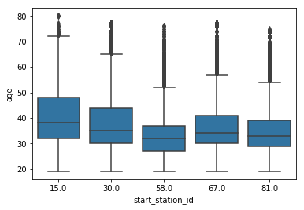

```python
# Focus on busiest 5 start stations.
# Rental counts for these range from 33716 to38461.
# Counts from left to right: 38461,37617,35092,34918,33716

base_color = sb.color_palette()[0]
sb.boxplot(x='start_station_id', y='age', data=df_age_busy, color=base_color)
```

## ...

#### Focus on least busiest 5 start stations. Plot ages for individual station ids.

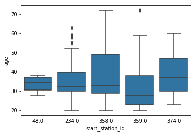

```python
# Plot same for least busiest 5 start stations.
# Rental counts for these ids from left to right: 174,91,52,25,11

base_color = sb.color_palette()[0]
sb.boxplot(x='start_station_id', y='age', data=df_age_notBusy, color=base_color);
```

## ...

### Look at relationship between age and user_type

#### Look at relationship between age and user_type at busiest start stations

```python
df_age_busy.user_type.value_counts()
```

```
Subscriber    149795
Customer       18578
Name: user_type, dtype: int64
```

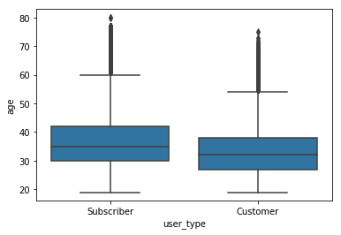

```python
base_color = sb.color_palette()[0]
sb.boxplot(x='user_type', y='age', data=df_age_busy, color=base_color);
```

#### Comment

- Median age for both subscribers and customers is similar, about 31-34.
- Note: subscribers outnumber customers 8 to 1.
- Although counts are markedly different the bulk of customer and subscriber ages are similar.

### ...

#### Look at age and user_type at least busy stations

```python
df_age_notBusy.user_type.value_counts()
```

```
Subscriber    242
Customer       86
Name: user_type, dtype: int64
```

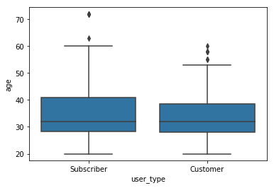

```python
base_color = sb.color_palette()[0]
sb.boxplot(x='user_type', y='age', data=df_age_notBusy, color=base_color);
```

#### Comment

- Median age for both subscribers and customers is similar, about 31.
- Note: subscribers outnumber customers about 3 to 1.
- Subscribers have a wider concentrated age grouping than customers.